# Geospatial Analysis Project: Analyze Crime Data

#### Calculate Moran’s I

```r
# create spatial neighbors
nb <- poly2nb(df_crime_geo)
lw <- nb2listw(nb, style = "W", zero.policy = TRUE)

# run Local Moran's I
local_moran <- localmoran(df_crime_geo$crime_count, lw, zero.policy = TRUE)

# add results
df_crime_geo$local_I <- local_moran[, "Ii"]
df_crime_geo$p_val <- local_moran[, "Pr(z != E(Ii))"]
```

Classify into LISA quadrants

```r
# compute global mean and lagged mean
mean_crime <- mean(df_crime_geo$crime_count, na.rm = TRUE)
lagged_crime <- lag.listw(lw, df_crime_geo$crime_count)

df_crime_geo$quadrant <- case_when(
  df_crime_geo$crime_count > mean_crime & lagged_crime > mean_crime & df_crime_geo$p_val < 0.05 ~ "High-High",
  df_crime_geo$crime_count < mean_crime & lagged_crime < mean_crime & df_crime_geo$p_val < 0.05 ~ "Low-Low",
  df_crime_geo$crime_count > mean_crime & lagged_crime < mean_crime & df_crime_geo$p_val < 0.05 ~ "High-Low",
  df_crime_geo$crime_count < mean_crime & lagged_crime > mean_crime & df_crime_geo$p_val < 0.05 ~ "Low-High",
  TRUE ~ "Non-significant"
)
```

Plot LISA map

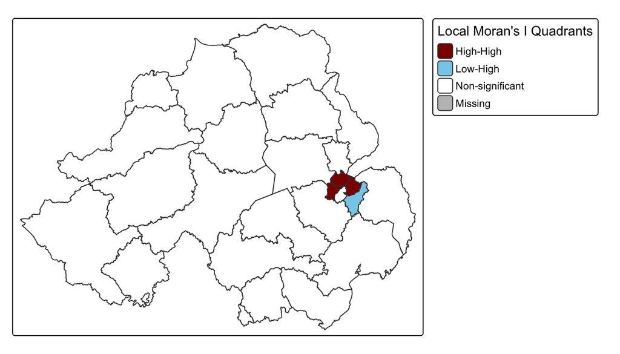

```r
tm_shape(df_crime_geo) +
  tm_polygons("quadrant",
              palette = c(
                "High-High" = "darkred",
                "Low-Low" = "steelblue",
                "High-Low" = "pink",
                "Low-High" = "skyblue",
                "Non-significant" = "white"
              ),
              title = "Local Moran's I Quadrants") +
  tm_layout(legend.outside = TRUE)
```

```r
# save to .png
tmap_save(
  tm = tm_shape(df_crime_geo) +
    tm_polygons("quadrant",
                palette = c(
                  "High-High" = "darkred",
                  "Low-Low" = "steelblue",
                  "High-Low" = "pink",
                  "Low-High" = "skyblue",
                  "Non-significant" = "white"
                ),
                title = "Local Moran's I Quadrants") +
    tm_layout(legend.outside = TRUE),
  filename = "plots/lisa_map_ni_geo.png",
  width = 2000,
  height = 1600,
  units = "px",
  dpi = 300
)
```

How to interpret:

- High-High (dark red): Areas with high crime surrounded by other high-crime areas, pointing to crime hotspots
- Low-High (light blue): Areas with low crime surrounded by high-crime areas, possibly indicating under-policed or isolated areas
- Non-significant (white): No clear spatial pattern found, could be random
- High-High cluster in and around Belfast indicates a crime center surrounded by similar areas
- the Low-High area next to Belfast may point to a suburban region that surrounds the urban center with more crime

#### Use Super Output Areas (SOA)

Granular data downloaded from: https://www.nisra.gov.uk/support/output-geography-census-2011/super-output-areas-census-2011?utm_source=chatgpt.com#toc-2

Northern Ireland doesn’t use LSOAs like England or Wales, but similar fine units include Super Output Areas (SOAs) and Small Areas (SAs). Northern Ireland contains 890 SOAs, each with about 2000 people per unit. SAs are even smaller, containing only about 125 households.

Load shapefile with SOA boundary polygons

```r
df_soa_ni <- st_read("data/in/SOA2011_esri_Shapefile/SOA2011.shp") %>%
  st_zm() %>%
  mutate(soa_id = paste0("SOA_", row_number()))
```

Convert crime data to sf points and match CRS

```r
# transform crime data to match SOA CRS
df_crime_ni <- st_transform(df_crime_ni, st_crs(df_soa_ni))
```

Join crimes to SOA areas

```r
df_crime_soa_ni <- st_join(df_crime_ni, df_soa_ni, join = st_within)
```

Aggregate crimes by SOA

```r
crime_counts <- df_crime_soa_ni %>%
  st_drop_geometry() %>%
  group_by(soa_id) %>%
  summarise(crime_count = n(), .groups = "drop")

df_crime_soa <- df_soa_ni %>%
  left_join(crime_counts, by = "soa_id") %>%
  mutate(crime_count = ifelse(is.na(crime_count), 0, crime_count))
```

#### Plot cloropleth

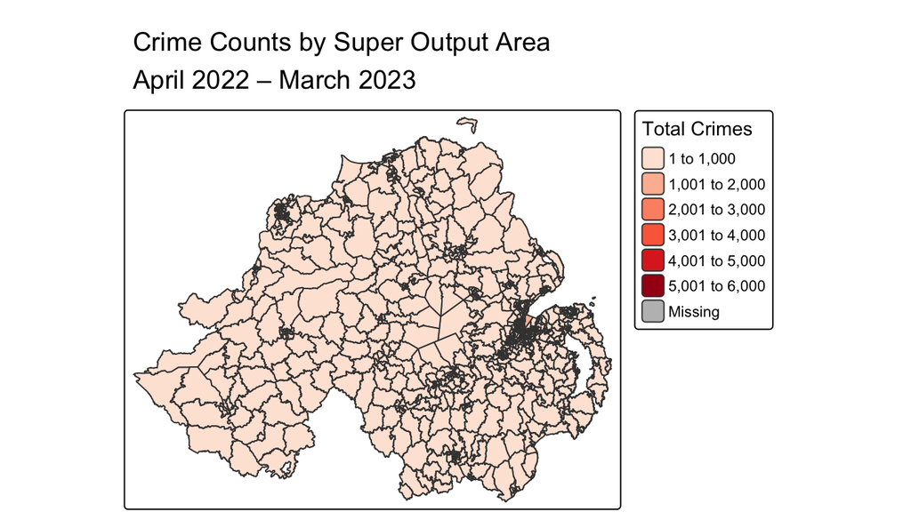

```r
# plot
tm_shape(df_crime_soa) +
  tm_polygons("crime_count",
              palette = "brewer.reds",
              title = "Total Crimes") +
  tm_layout(
    main.title = "Crime Counts by Super Output Area\nApril 2022 – March 2023",
    main.title.size = 1.2,
    main.title.position = "center",
    legend.outside = TRUE
  )
```

```r
# save cloropleth
tmap_save(
  filename = "plots/crime_choropleth_ni_soa.png",
  width = 2000, height = 1600, dpi = 300
)
```

#### Calculate Moran’s I

```r
nb <- poly2nb(df_crime_soa)
lw <- nb2listw(nb, style = "W", zero.policy = TRUE)
local_moran <- localmoran(df_crime_soa$crime_count, lw, zero.policy = TRUE)

df_crime_soa$local_I <- local_moran[, "Ii"]
df_crime_soa$p_val   <- local_moran[, "Pr(z != E(Ii))"]

mean_crime <- mean(df_crime_soa$crime_count, na.rm = TRUE)
lagged_crime <- lag.listw(lw, df_crime_soa$crime_count)

df_crime_soa$quadrant <- case_when(
  df_crime_soa$crime_count > mean_crime & lagged_crime > mean_crime & df_crime_soa$p_val < 0.05 ~ "High-High",
  df_crime_soa$crime_count < mean_crime & lagged_crime < mean_crime & df_crime_soa$p_val < 0.05 ~ "Low-Low",
  df_crime_soa$crime_count > mean_crime & lagged_crime < mean_crime & df_crime_soa$p_val < 0.05 ~ "High-Low",
  df_crime_soa$crime_count < mean_crime & lagged_crime > mean_crime & df_crime_soa$p_val < 0.05 ~ "Low-High",
  TRUE ~ "Non-significant"
)
```

Plot LISA map with quadrants

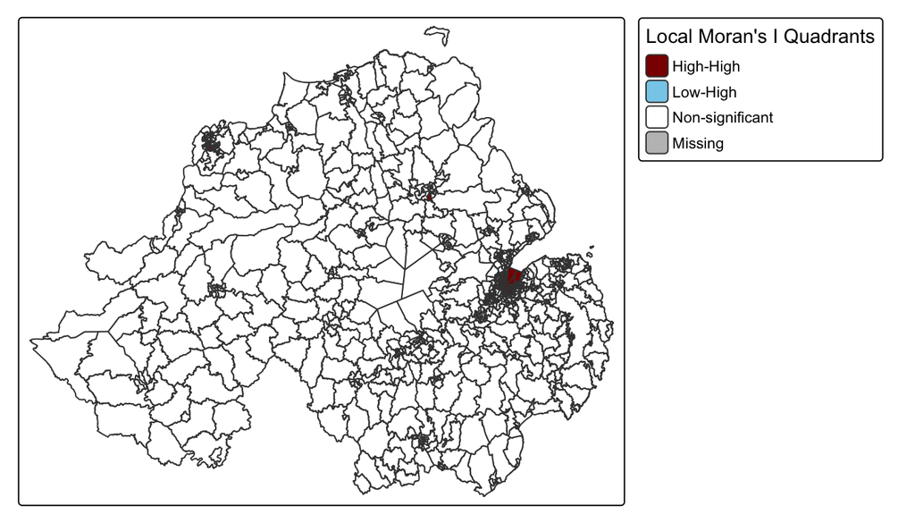

```r
tm_shape(df_crime_soa) +
  tm_polygons("quadrant",
              palette = c(
                "High-High" = "darkred",
                "Low-Low" = "steelblue",
                "High-Low" = "pink",
                "Low-High" = "skyblue",
                "Non-significant" = "white"
              ),
              title = "Local Moran's I Quadrants") +
  tm_layout(legend.outside = TRUE)
```